# ↩️ Pipelines 4 All 🔀

### From Data Engineering to Machine Learning

### PyCon APAC 2021

Ramon Perez  
19 November 2021  
From Sydney With ❤️

## Agenda 4 Today

1. Scenario/Motivation
2. What are Pipelines?
3. Why Should You Care?
4. Hands-On Tutorial

## 1. Scenario/Motivation

As a Data Analyst, have you ever found yourself in the following scenario?

Imagine you have a data in a database with information regarding London's public Bike Sharing system, and that you've been asked to derive some insights from that dataset. Your process usually goes as follows.

1. Locate the data.
2. Write a SQL query to retrieve the data.
3. Open up a spreadsheet to clean it and manipulate it.
4. Throw the data in a notebook, at Tableau or your BI tool of choice and find insights.
5. ...

**Let's put this into perspective**

## Step 1 - The Data

```python
!head -n 5 ../data/01_part/raw/london/london_merged.csv
```

```
timestamp,cnt,t1,t2,hum,wind_speed,weather_code,is_holiday,is_weekend,season
2015-01-04 00:00:00,182,3.0,2.0,93.0,6.0,3.0,0.0,1.0,3.0
2015-01-04 01:00:00,138,3.0,2.5,93.0,5.0,1.0,0.0,1.0,3.0
2015-01-04 02:00:00,134,2.5,2.5,96.5,0.0,1.0,0.0,1.0,3.0
2015-01-04 03:00:00,72,2.0,2.0,100.0,0.0,1.0,0.0,1.0,3.0
```

## Step 2 - Your Query

```
Select *

From my_table

ORDER BY date;
```

## Step 3 - Some Spreadsheet Magic

[figure not shown]

## Step 4 - From Clean Data to Your Favorite BI Tool

Uncover insights through data visualization with your BI Tool of choice, and create a dashboard to share your results.

[figure not shown]

## Your New Favorite Animal 🐼

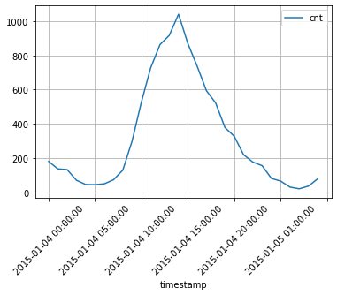

```python
pd.read_sql('SELECT * FROM bikes_table ORDER BY timestamp',
            connection).pipe(cleaning_function).plot(x='timestamp', y='cnt', rot=45)
```

# 2. What are pipelines?

[figure not shown]

> A pipeline is a process used to run, among many things, data or other pieces of information through a series of steps.

Many data professionals build pipelines for a living, for example:

## 2.1 Data Engineers

[figure not shown]

Usually worry about the movement and transformation of data for ease of use.

## 2.2 Data Analysts

[figure not shown]

Automate the ingestion of data, the creation of visualization, and the consumption of insights through reports and dashboards.

## 2.3 DevOps Engineers

[figure not shown]

Create robust pipelines that test, inspect, verify, and deploy entire systems and infrastructures.

## 2.4 Data Scientists

[figure not shown]

Create experiments and models that depend on specific engineering steps not provided in the transform part of an ETL pipeline. The output of these pipelines can be a product, decision or idea.

## 2.5 Machine Learning Engineers (and MLOps)

[figure not shown]

Create robust systems that train, save, deploy and monitor machine learning models.

## 3 Why Should you Care?

When you have to load, clean a bit, and then do something useful, you are creating a pipeline. Hence, any process involving more than one step can be considered a pipeline and, as such, it should be treated as one. Why?

- Automating the steps of your pipeline can save you time, money, and other resources.
- Automating these steps allows you to create robust tests around your pipelines.
- Increases reproducibility and consistency.
- Enables data professionals across the organization to work on different tasks.

## Hands-On Tutorial Time

[figure not shown]

# Thank You!

[figure not shown]